# Project

```python
import pandas as pd
import numpy as np
import seaborn as sns
import matplotlib.pyplot as plt
import warnings
warnings.filterwarnings("ignore")
```

```python
df=pd.read_csv(r"C:\Users\HP\Downloads\marketing_campaign_performance_10000.csv")
```

```python
df
```

|  | CampaignID | StartDate | EndDate | Channel | Impressions | Clicks | Leads | Conversions | Cost_USD | Revenue_USD | ROI |
| --- | --- | --- | --- | --- | --- | --- | --- | --- | --- | --- | --- |
| 0 | CAMP00001 | 2025-04-13 | 2025-04-19 | Search | 293520 | 23335 | 11643 | 5389 | 1052.39 | 2236.02 | 1.12 |
| 1 | CAMP00002 | 2025-12-15 | 2025-12-24 | Search | 200340 | 15841 | 6601 | 2498 | 3964.90 | 11740.15 | 1.96 |
| 2 | CAMP00003 | 2025-09-28 | 2025-10-06 | Email | 239365 | 16478 | 8043 | 3397 | 1000.39 | 1902.24 | 0.90 |
| 3 | CAMP00004 | 2025-04-17 | 2025-04-30 | Search | 156382 | 2672 | 1014 | 342 | 1252.63 | 2209.74 | 0.76 |
| 4 | CAMP00005 | 2025-03-13 | 2025-03-22 | Influencer | 285472 | 4155 | 1521 | 565 | 4935.48 | 14111.31 | 1.86 |
| ... | ... | ... | ... | ... | ... | ... | ... | ... | ... | ... | ... |
| 9995 | CAMP09996 | 2025-05-28 | 2025-06-03 | Influencer | 112030 | 1896 | 627 | 152 | 4491.36 | 12415.83 | 1.76 |
| 9996 | CAMP09997 | 2025-12-31 | 2026-01-06 | Search | 177412 | 11529 | 2021 | 955 | 761.85 | 1214.01 | 0.59 |
| 9997 | CAMP09998 | 2025-12-30 | 2026-01-07 | Social | 41892 | 4098 | 940 | 470 | 116.84 | 339.12 | 1.90 |
| 9998 | CAMP09999 | 2025-05-20 | 2025-05-28 | Social | 141674 | 10697 | 1834 | 385 | 2885.00 | 6580.54 | 1.28 |
| 9999 | CAMP10000 | 2025-07-09 | 2025-07-15 | Email | 85957 | 6098 | 2670 | 821 | 4938.19 | 6883.68 | 0.39 |

10000 rows × 11 columns

```python
df.shape
```

```
(10000, 11)
```

```python
df.size
```

```
110000
```

```python
df.info()
```

```
<class 'pandas.core.frame.DataFrame'>
RangeIndex: 10000 entries, 0 to 9999
Data columns (total 11 columns):
 #   Column       Non-Null Count  Dtype
---  ------       --------------  -----
 0   CampaignID   10000 non-null  object
 1   StartDate    10000 non-null  object
 2   EndDate      10000 non-null  object
 3   Channel      10000 non-null  object
 4   Impressions  10000 non-null  int64
 5   Clicks       10000 non-null  int64
 6   Leads        10000 non-null  int64
 7   Conversions  10000 non-null  int64
 8   Cost_USD     10000 non-null  float64
 9   Revenue_USD  10000 non-null  float64
 10  ROI          10000 non-null  float64
dtypes: float64(3), int64(4), object(4)
memory usage: 859.5+ KB
```

```python
df.columns
```

```
Index(['CampaignID', 'StartDate', 'EndDate', 'Channel', 'Impressions',
       'Clicks', 'Leads', 'Conversions', 'Cost_USD', 'Revenue_USD', 'ROI'],
      dtype='object')
```

```python
df.dtypes
```

```
CampaignID      object
StartDate       object
EndDate         object
Channel         object
Impressions      int64
Clicks           int64
Leads            int64
Conversions      int64
Cost_USD       float64
Revenue_USD    float64
ROI            float64
dtype: object
```

```python
df.head()
```

|  | CampaignID | StartDate | EndDate | Channel | Impressions | Clicks | Leads | Conversions | Cost_USD | Revenue_USD | ROI |
| --- | --- | --- | --- | --- | --- | --- | --- | --- | --- | --- | --- |
| 0 | CAMP00001 | 2025-04-13 | 2025-04-19 | Search | 293520 | 23335 | 11643 | 5389 | 1052.39 | 2236.02 | 1.12 |
| 1 | CAMP00002 | 2025-12-15 | 2025-12-24 | Search | 200340 | 15841 | 6601 | 2498 | 3964.90 | 11740.15 | 1.96 |
| 2 | CAMP00003 | 2025-09-28 | 2025-10-06 | Email | 239365 | 16478 | 8043 | 3397 | 1000.39 | 1902.24 | 0.90 |
| 3 | CAMP00004 | 2025-04-17 | 2025-04-30 | Search | 156382 | 2672 | 1014 | 342 | 1252.63 | 2209.74 | 0.76 |
| 4 | CAMP00005 | 2025-03-13 | 2025-03-22 | Influencer | 285472 | 4155 | 1521 | 565 | 4935.48 | 14111.31 | 1.86 |

```python
df.tail()
```

|  | CampaignID | StartDate | EndDate | Channel | Impressions | Clicks | Leads | Conversions | Cost_USD | Revenue_USD | ROI |
| --- | --- | --- | --- | --- | --- | --- | --- | --- | --- | --- | --- |
| 9995 | CAMP09996 | 2025-05-28 | 2025-06-03 | Influencer | 112030 | 1896 | 627 | 152 | 4491.36 | 12415.83 | 1.76 |
| 9996 | CAMP09997 | 2025-12-31 | 2026-01-06 | Search | 177412 | 11529 | 2021 | 955 | 761.85 | 1214.01 | 0.59 |
| 9997 | CAMP09998 | 2025-12-30 | 2026-01-07 | Social | 41892 | 4098 | 940 | 470 | 116.84 | 339.12 | 1.90 |
| 9998 | CAMP09999 | 2025-05-20 | 2025-05-28 | Social | 141674 | 10697 | 1834 | 385 | 2885.00 | 6580.54 | 1.28 |
| 9999 | CAMP10000 | 2025-07-09 | 2025-07-15 | Email | 85957 | 6098 | 2670 | 821 | 4938.19 | 6883.68 | 0.39 |

```python
df.isnull().sum()
```

```
CampaignID     0
StartDate      0
EndDate        0
Channel        0
Impressions    0
Clicks         0
Leads          0
Conversions    0
Cost_USD       0
Revenue_USD    0
ROI            0
dtype: int64
```

```python
df.describe()
```

|  | Impressions | Clicks | Leads | Conversions | Cost_USD | Revenue_USD | ROI |
| --- | --- | --- | --- | --- | --- | --- | --- |
| count | 10000.000000 | 10000.000000 | 10000.000000 | 10000.000000 | 10000.000000 | 10000.000000 | 10000.000000 |
| mean | 152260.637900 | 8338.993300 | 2512.463600 | 1010.700000 | 2552.356991 | 5102.648930 | 1.001576 |
| std | 85251.707621 | 6546.326431 | 2321.031302 | 1019.402613 | 1427.694545 | 3309.326705 | 0.578806 |
| min | 5043.000000 | 72.000000 | 10.000000 | 4.000000 | 100.230000 | 113.640000 | 0.000000 |
| 25% | 78956.000000 | 2981.000000 | 779.000000 | 295.000000 | 1319.622500 | 2385.742500 | 0.500000 |
| 50% | 151505.500000 | 6588.500000 | 1777.000000 | 670.000000 | 2529.675000 | 4659.365000 | 0.990000 |
| 75% | 225853.250000 | 12404.250000 | 3550.250000 | 1391.000000 | 3821.307500 | 7241.245000 | 1.510000 |
| max | 299997.000000 | 29578.000000 | 13833.000000 | 7987.000000 | 4998.420000 | 14871.340000 | 2.000000 |

```python
df.duplicated().sum()
```

```
np.int64(0)
```

```python
df.nunique()
```

```
CampaignID     10000
StartDate        365
EndDate          375
Channel            5
Impressions     9836
Clicks          7741
Leads           4941
Conversions     2909
Cost_USD        9889
Revenue_USD     9964
ROI              201
dtype: int64
```

```python
df["Channel"].value_counts()
```

```
Channel
Display       2069
Influencer    2056
Email         1996
Social        1955
Search        1924
Name: count, dtype: int64
```

## Univariate Analysis

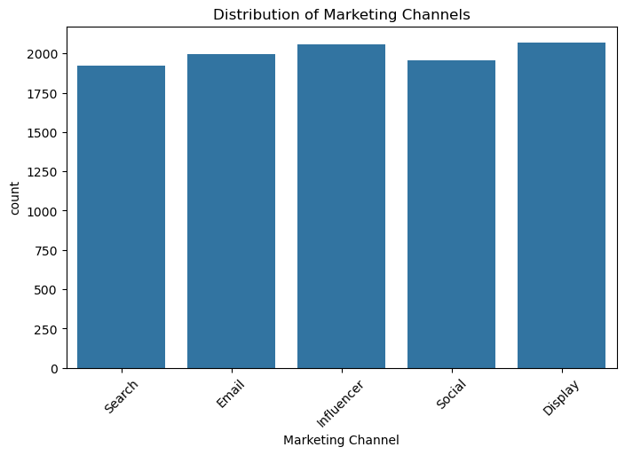

```python
plt.figure(figsize=(8,5))
sns.countplot(x="Channel",data=df)
plt.title("Distribution of Marketing Channels")
plt.xlabel("Marketing Channel")
plt.ylabel("count")
plt.xticks(rotation=45)
plt.show()
```

## Interpretation

#### - Marketing campaigns are evenly distributed across all channels.

#### - No single channel dominates the dataset.

#### - This balanced distribution makes the data fair for comparison and analysis

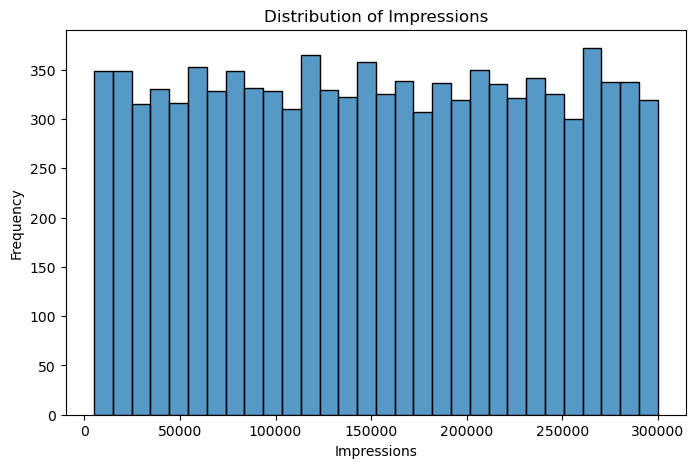

```python
plt.figure(figsize=(8,5))
sns.histplot(df["Impressions"],bins=30,)
plt.title("Distribution of Impressions")
plt.xlabel("Impressions")
plt.ylabel("Frequency")
plt.show()
```

## Interpretation

#### - The histogram shows the distribution of Impressions across all campaigns.

#### - Impressions are fairly evenly distributed.

#### - No single impression range has a significantly higher frequency.

#### - This indicates a balanced campaign reach.

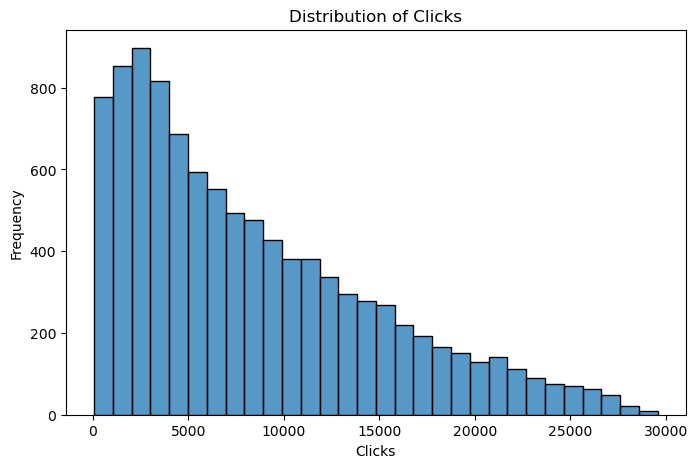

```python
plt.figure(figsize=(8,5))
sns.histplot(df["Clicks"],bins=30)
plt.title("Distribution of Clicks")
plt.xlabel("Clicks")
plt.ylabel("Frequency")
plt.show()
```

## Interpretation

#### - Displays the distribution of clicks.

#### - Most campaigns received low to moderate clicks.

#### - Only a few campaigns generated very high clicks.

#### - The distribution is positively skewed,indicating that high click campaigns are less common.

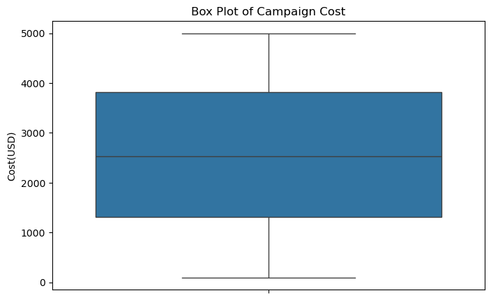

```python
plt.figure(figsize=(8,5))
sns.boxplot(y=df["Cost_USD"])
plt.title("Box Plot of Campaign Cost")
plt.ylabel("Cost(USD)")
plt.show()
```

## Interpretation

#### - The box plot shows the distribution of campaign cost (USD).

#### - The campaign costs are spread across a wide range.

#### - No significant outliers are observed.

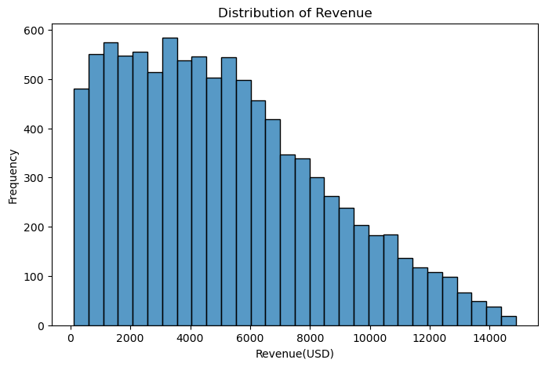

```python
plt.figure(figsize=(8,5))
sns.histplot(df["Revenue_USD"],bins=30)
plt.title("Distribution of Revenue")
plt.xlabel("Revenue(USD)")
plt.ylabel("Frequency")
plt.show()
```

## Interpretation

#### - The histogram shows how revenue is distributed across different marketing campaigns.

#### - Most campaigns generated revenue in the lower to middle range.

#### - As revenue increases the number of campaigns gradually decreases.

#### - This idicates that high revenue campaigns are fewer while most campaigns generate moderate revanue

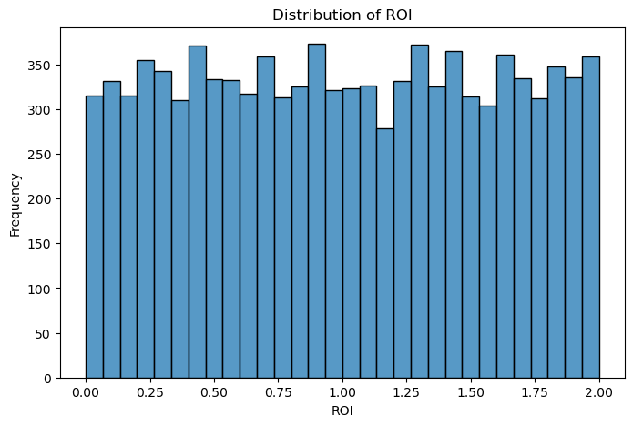

```python
plt.figure(figsize=(8,5))
sns.histplot(df["ROI"],bins=30)
plt.title("Distribution of ROI")
plt.xlabel("ROI")
plt.ylabel("Frequency")
plt.show()
```

## Interpretation

#### - This histogram shows the distribution of ROI across all marketing campaigns.

#### - ROI values are fairly evenly distributed across different ranges.

#### - This indicates that campaigns achieved balanced returne on investment.

## Bivariate Analysis

```python
df.groupby("Channel")["Revenue_USD"].mean()
```

```
Channel
Display       5178.890870
Email         5075.422149
Influencer    5135.271882
Search        5144.323176
Social        4974.437187
Name: Revenue_USD, dtype: float64
```

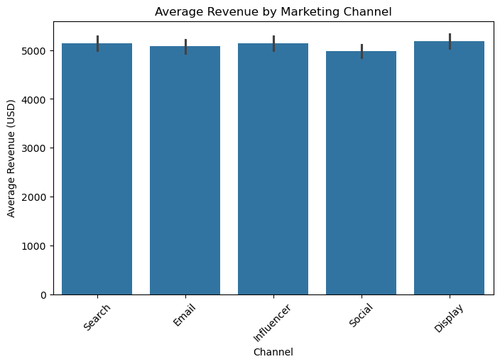

```python
plt.figure(figsize=(8,5))
sns.barplot(x="Channel",y="Revenue_USD",data=df)
plt.title("Average Revenue by Marketing Channel")
plt.xlabel("Channel")
plt.ylabel("Average Revenue (USD)")
plt.xticks(rotation=45)
plt.show()
```

#### - Display performed the best in average revenue.

#### - Social performed the least.

#### - Most channels showed similar revenue performance

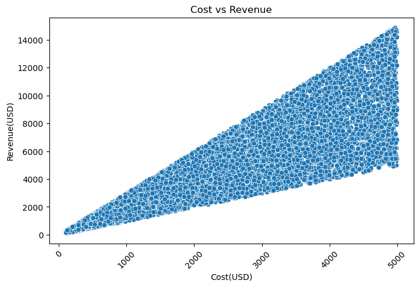

```python
plt.figure(figsize=(8,5))
sns.scatterplot(x="Cost_USD",y="Revenue_USD",data=df)
plt.title("Cost vs Revenue")
plt.xlabel("Cost(USD)")
plt.ylabel("Revenue(USD)")
plt.xticks(rotation=45)
plt.show()
```

## Interpretation

#### - The scatter plot shows the relationship between campaign cost and revenue.

#### - As the campaign cost increases the revenue also generally increases.

#### - This indicates a positive relationship between cost and revenue.

#### - Higher investment in campaigns is generally associated with higher revenue.

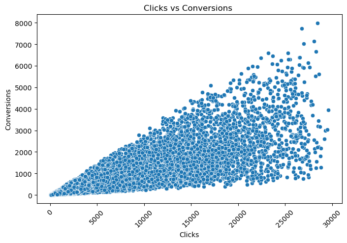

```python
plt.figure(figsize=(8,5))
sns.scatterplot(x="Clicks",y="Conversions",data=df)
plt.title("Clicks vs Conversions ")
plt.xlabel("Clicks")
plt.ylabel("Conversions")
plt.xticks(rotation=45)
plt.show()
```

## Interpretation

#### - The graph indicates that campaigns attracting more user clicks tend to generate more conversion.

#### - Most data points follow an upward trend showing a posistive relationship.

#### - This means improving clicks can contribute to better campaign performance.

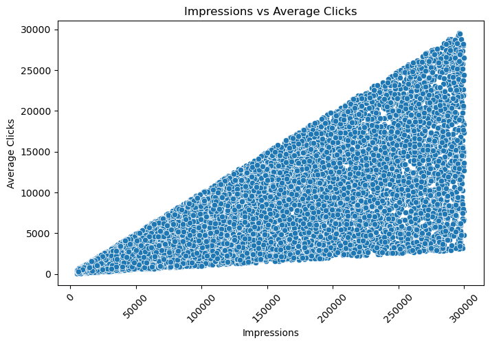

```python
plt.figure(figsize=(8,5))
sns.scatterplot(x="Impressions",y="Clicks",data=df)
plt.title("Impressions vs Average Clicks")
plt.xlabel("Impressions")
plt.ylabel("Average Clicks")
plt.xticks(rotation=45)
plt.show()
```

### The graph shows a positive relationship between impressions and clicks.As impression increase clicks generally increase.

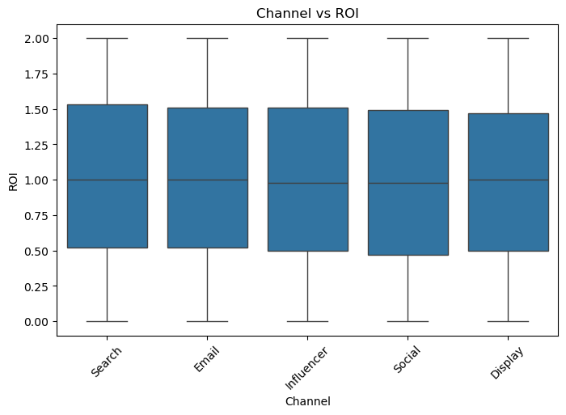

```python
plt.figure(figsize=(8,5))
sns.boxplot(x="Channel",y="ROI",data=df)
plt.title("Channel vs ROI")
plt.xticks(rotation=45)
plt.show()
```

## Interpretation

#### - ROI is almost similar across all marketing channels.

#### - No channel has a significantly higher or lower ROI.

#### - Overall,all channels show comparable performance.

## Multivariate Analysis

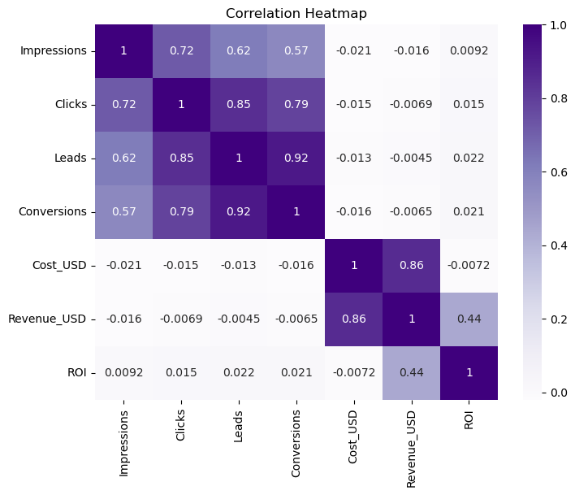

```python
plt.figure(figsize=(8,6))
sns.heatmap(df.corr(numeric_only=True),annot=True,cmap="Purples")
plt.title("Correlation Heatmap")
plt.show()
```

## Interpretation

#### - Impressions,Clicks,Leads,and Conversions show a strong positive relationship,meaning they increase together.

#### - Leads and Convertions have the strongest correlation (0.92),indicating that more leads usually result in more conversions.

#### - Cost and Revenue also have a strong positive correlation(0.86),suggesting that higher campaign spending generally generates higher revenue.

#### - ROI has only a moderate relationship with Revenue (0.44) and a weak relationship with the other variables.

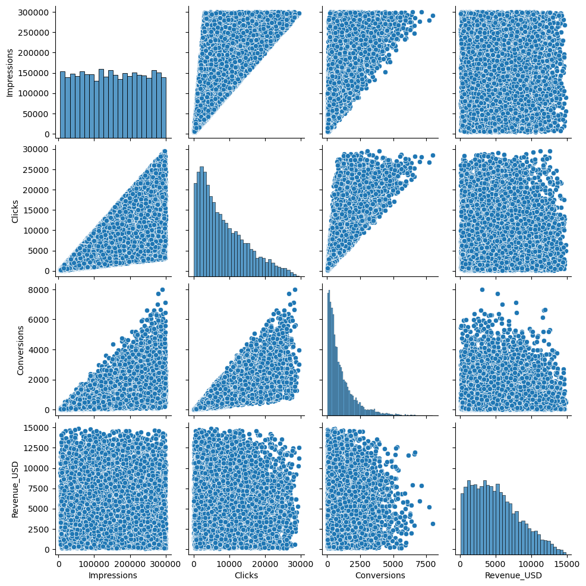

```python
sns.pairplot(df[["Impressions",
                 "Clicks",
                 "Conversions",
                 "Revenue_USD"]])
plt.show()
```

## Interpretation

#### - The pair plot compares multiple numerical variable together.

#### - Impressions,Clicks,and Conversions show a positive relationship.As impression increases,clicks

#### and conversion also tend to increase.

#### - Revenue does not have a strong relationship with the other variables.Higher impressions,clicks

#### or conversions do not always result in higher revenue.

#### - The diagonal histogram show the distribution of each variables.Most observations are concentrated

#### at lower values,especially for clicks,conversions,and revenue.

#### - The scatter plots show a wide spread of data points.This indicates that the relationship between

#### some variables is not very strong.

#### - overall,customer engagement follows a positive trend ,while Revenue appears to be influanced by additional factors.

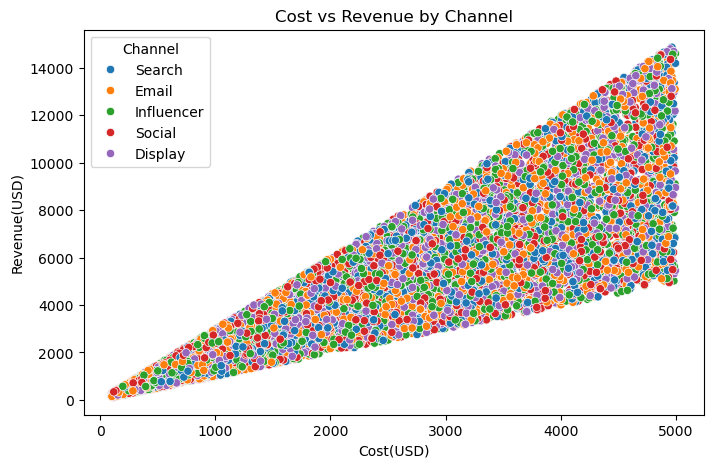

```python
plt.figure(figsize=(8,5))
sns.scatterplot(x="Cost_USD",
                y="Revenue_USD",
                hue="Channel",
                data=df)
plt.title("Cost vs Revenue by Channel")
plt.xlabel("Cost(USD)")
plt.ylabel("Revenue(USD)")
plt.show()
```

## Interpretation

#### - Cost and Revenue show a positive relationship.As campaign cost increases,revenue also tends to increase.

#### - All marketing channels follow a similar trend.No single channel clearly outperforms the others.

#### - The data points are widely spread.This suggests that revenue is influenced by factors other than cost.

#### - overall,higher campaign spending generally leads to higher revenue,regardless of the marketing channel.

# Conclusion

## The visualizations and correlation analysis also demonstrate the value of data-driven decision-making in marketing. By continuously monitoring campaign performance, identifying customer behavior, and optimizing marketing strategies, businesses can improve their return on investment (ROI). Overall, the findings suggest that successful marketing campaigns depend not only on higher spending but also on effective planning, audience targeting, and continuous performance improvement, helping organizations achieve sustainable business growth.